# Time_Series_Regression_I

# References

1. Hyndman, R.J., & Athanasopoulos, G., 2021. *Forecasting: principles and practice*. 3rd edition.
2. Fable package documentation
- https://fable.tidyverts.org/index.html
- https://fable.tidyverts.org/articles/fable.html
3. Shether - Linear models

# Note

This notebook is not original material, but rather taken from ref. 1 with notes expanding on some of the concepts contained in the book.

# Predictor variables and time series forecasting

Recall from the introduction to this subject (ref [1] section 1.4) the distinction between **time series models**, **exlpanatory models** and **mixed models**.

## **Time Series Models**

Those predict the valur of the varibable of interest $y$ at time $t+1$ using the values up to time $t$:

$$\begin{align*}
y_{t+1|t} = f(y_{t}, y_{t-1}, y_{t-2}, y_{t-3},\dots, \text{error}),
\end{align*}$$

## **Explanatory Models**

Uses **one or multiplepredictor variables** ($x_1, x_2, \dots, ..., x_n$) to predict the value of the variable of interest:

$$\begin{align*}
y = f(x_1, x_2, \dots, ..., x_n,\dots, \text{error})
\end{align*}$$

## **Mixed models**

Given different names in different disciplines. *Dynamic regression models* or *panel data models* or *longitudinal models*, *transfer function models* and *linear system models* (assuming that $f$ is linear):

$$\begin{align*}
y_{t+1|t} = f(y_{t}, y_{t-1}, y_{t-2}, y_{t-3}, \dots, x_1, x_2, \dots, ..., x_n, \dots, \text{error})
\end{align*}$$

These models are discussed in chapter 10 of ref [1] and we will briefly discuss them at the end of the subject.

## Scope and terminology

**This chapter is focused on explanatory models** assuming that **y has a linear relationship with other time series x**

Examples:

- Forecast monthly sales $y$ using total advertising spend $x$
- Forecast daily electricity demand $y$ using temperature $x_1$ and the day of the week $x_2$ has a predictor.

The variables receive the following names:

- The **forecast variable** $y$ is sometimes called the **regressand**, the **dependent** or the **explained variable**.
- The **predictor variables** $x$ are sometimes called the **regressors**, the **independent** or the **explanatory variables**.

# Simple Linear Regression

## General note on linear systems theory

This content has already been part of other subjects and therefore will be seen here without delving too much into the details of the underlying mathematical formulation. Rather we will focus as much as possible on the practicalities associated to their time series aspect.

## Formula

$$\begin{align*}
y_t = \beta_0 + \beta_1 x_t + \varepsilon_t.
\end{align*}$$

- $\beta_0$: intercept. Value of $y$ when $x=0$
- $\beta_1$: slope. Represents the **average** predicted change in y resulting from a one unit increase in x.
- $\varepsilon_t$: is the error or unexplained part of the model.

The figure below (from ref [1]) is an example of artificial data and such a model:

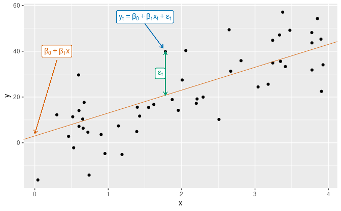

## Example: US Consumption Expenditure

We start with **two time series** tracking **quarterly percentage changes (growth rates)** from 1970 Q1 to 2019 Q2 for the following variables:

- Real consumption expenditure $y$.
- Real disposable income $x$,

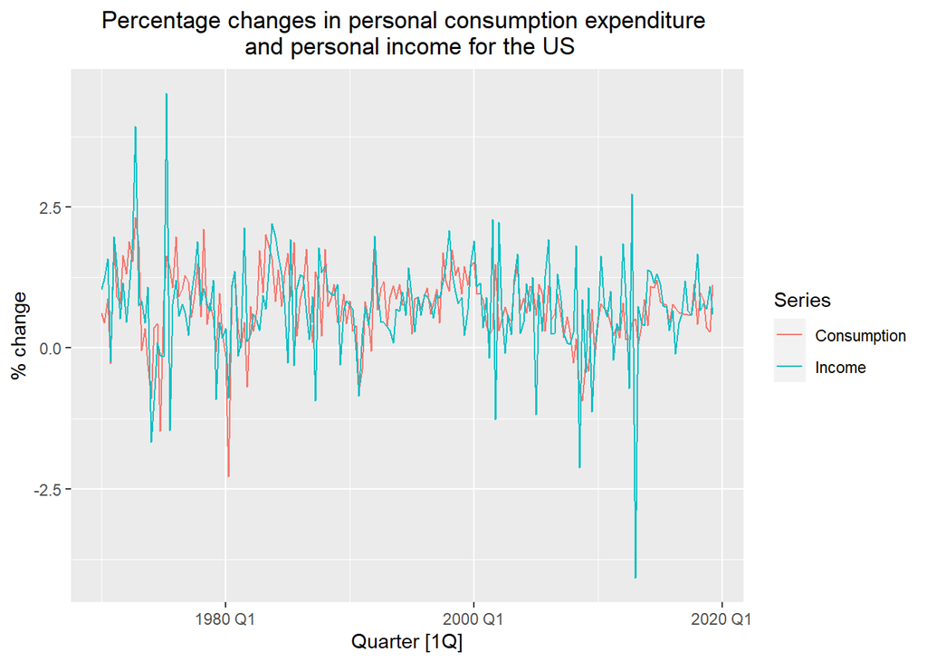

```r
us_change %>%
  pivot_longer(c(Consumption, Income), names_to="Series") %>%
  autoplot(value) +
  labs(y = "% change") +
  ggtitle("Percentage changes in personal consumption expenditure \n and personal income for the US") +
  theme(plot.title = element_text(hjust = 0.5))
```

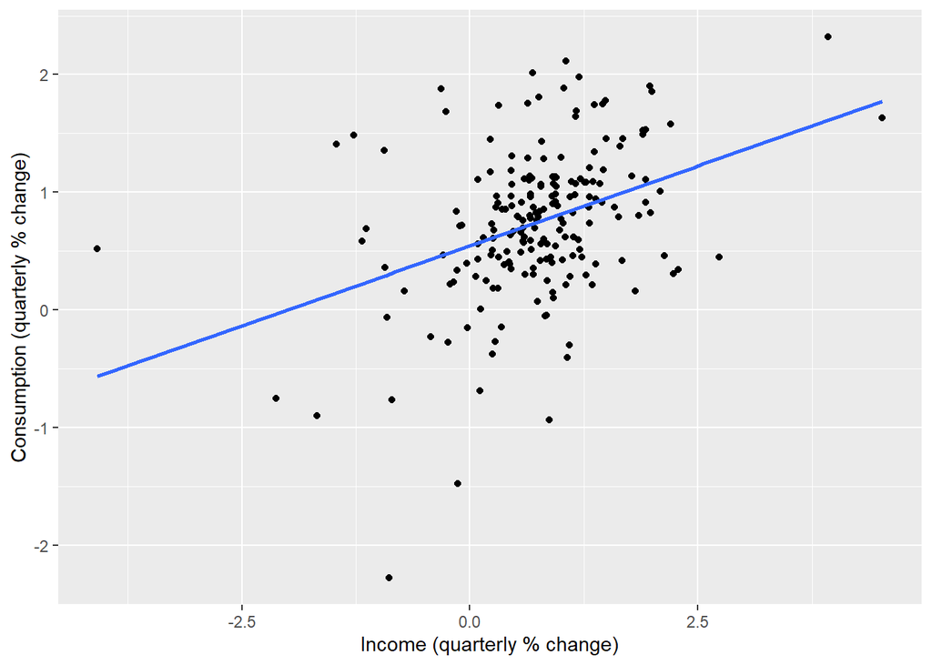

```r
us_change %>%
  ggplot(aes(x = Income, y = Consumption)) +
  labs(y = "Consumption (quarterly % change)",
       x = "Income (quarterly % change)") +
  geom_point() +
  geom_smooth(method = "lm", se = FALSE)
```

We may also fit the linear model sepparately using the function `lm` from `stats` or, **better in the time series context to remain consistent with the fable package formulation**, the function `TSLM` from the `fable` package (which uses `lm` under the hood).

```r
lm_1var <- lm(Consumption ~ Income, us_change)
lm_1var
```

```
Call:
lm(formula = Consumption ~ Income, data = us_change)

Coefficients:
(Intercept)       Income
     0.5445       0.2718
```

```r
TSLM_1var <-
  us_change %>%
  model(TSLM(Consumption ~ Income))

TSLM_1var
```

```
# A mable: 1 x 1
  `TSLM(Consumption ~ Income)`
                       <model>
1                       <TSLM>
```

The coefficients can be obtained as usual using `tidy()` or, alternatively, using `report()``

```r
TSLM_1var %>% tidy()
```

```
# A tibble: 2 x 6
  .model                     term        estimate std.error statistic  p.value
  <chr>                      <chr>          <dbl>     <dbl>     <dbl>    <dbl>
1 TSLM(Consumption ~ Income) (Intercept)    0.545    0.0540     10.1  1.63e-19
2 TSLM(Consumption ~ Income) Income         0.272    0.0467      5.82 2.40e- 8
```

```r
TSLM_1var %>% report()
```

```
Series: Consumption
Model: TSLM

Residuals:
     Min       1Q   Median       3Q      Max
-2.58236 -0.27777  0.01862  0.32330  1.42229

Coefficients:
            Estimate Std. Error t value Pr(>|t|)
(Intercept)  0.54454    0.05403  10.079  < 2e-16 ***
Income       0.27183    0.04673   5.817  2.4e-08 ***
---
Signif. codes:  0 '***' 0.001 '**' 0.01 '*' 0.05 '.' 0.1 ' ' 1

Residual standard error: 0.5905 on 196 degrees of freedom
Multiple R-squared: 0.1472, Adjusted R-squared: 0.1429
F-statistic: 33.84 on 1 and 196 DF, p-value: 2.4022e-08
```

The fitted model is (note that $\hat{y}$ indicates value predicted by the model):

$$\begin{align*}
\hat{y}_t=0.54 + 0.27x_t.
\end{align*}$$

### Interpretation of the coefficients

- **Slope coefficient** an increment of 1 percentage point in personal disposable income results **on average** in 0.27 percent points increase in personal consumption expenditure.
- **Intercept**: its interpretation requires that a value of $x=0$ makes sense.
  - Here, when $x=0$ (no change in personal disposable income since the last quarter), the predicted value of $y$ is 0.54 (an average increase in personal consumption expenditure of 0.54%)
  - Even when $x=0$ is non-sensical, **the intercept is an important part of the model**. Without it, **the slope coefficient can be unnecessarily distorted. We assume that an intercept (however small) is always included in the model.

### NOTE

The syntax to remove the intercept term is not intuitive. See the documentation of `lm`. Example:

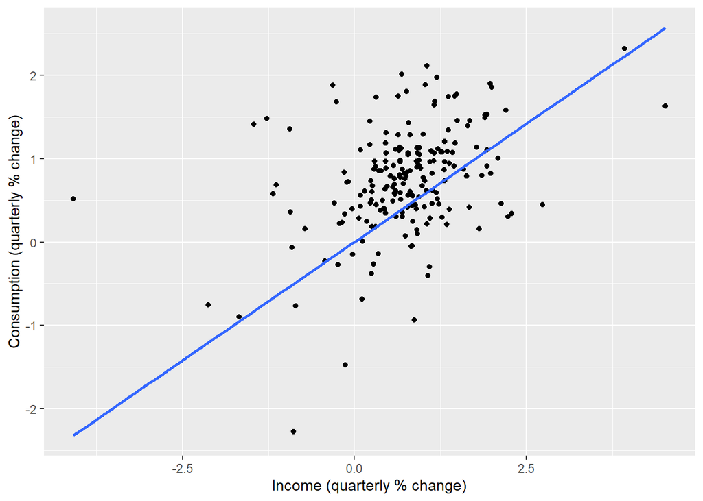

```r
us_change %>%
  ggplot(aes(x = Income, y = Consumption)) +
  labs(y = "Consumption (quarterly % change)",
       x = "Income (quarterly % change)") +
  geom_point() +
  geom_smooth(method = "lm", formula="y ~ 0 + x", se = FALSE)
```

Or alternatively in model form:

```r
us_change %>%
  model(TSLM(Consumption ~ 0 + Income)) %>%
  tidy()
```

```
# A tibble: 1 x 6
  .model                         term   estimate std.error statistic  p.value
  <chr>                          <chr>     <dbl>     <dbl>     <dbl>    <dbl>
1 TSLM(Consumption ~ 0 + Income) Income    0.568    0.0446      12.7 1.62e-27
```

# Multiple linear regression

When there are multiple predictors, we talk of **multiple regression model**. The general form of the model is:

$$\begin{equation}
y_t = \beta_{0} + \beta_{1} x_{1,t} + \beta_{2} x_{2,t} + \cdots + \beta_{k} x_{k,t} + \varepsilon_t
\end{equation}$$

In this case, the coefficients of each regressor receive the name **marginal effects** of the predictor variable. They represent the average change in the forecast variable per unit increase of each of the regressors.

**NOTE**: the expression *ceteris paribus* (all other things being equal) can be used in the context of multi-variable regression to indicate that an assertion/analysis is made considering only changes in one of the regressors, holding all other variables constant.

## Least squares estimation

The coefficients that best match the model need to be estimated from the data. As you have studied in other subjects, for linear regression the usual Least Squares Principle minimizes the sum of square errors. In other words, $\beta_0, \beta_1, \dots, \beta_k$ are chosen to minimize:

$$\begin{align*}
\sum_{t=1}^T \varepsilon_t^2 = \sum_{t=1}^T (y_t -
\beta_{0} - \beta_{1} x_{1,t} - \beta_{2} x_{2,t} - \cdots - \beta_{k} x_{k,t})^2.
\end{align*}$$

The resulting coefficients are *estimations*, in the sense that they are estimations derived from a finite sample rather than from the totality of the population of the phenomena. The notation used for these is $\hat\beta_0, \dots, \hat\beta_k$

For linear regression, there are explicit formulas. These are given in section [7.9](https://otexts.com/fpp3/regression-matrices.html) of reference [1] and can be found on virtually every book on linear regression. These have been part of other subjects and will not be reproduced here.

The methods we will be using in linear regression have this linear squared minimization principle implemented. Sometimes it is also referred to as *optimal least squares* (ols)

## Example: additional regressors in US consumption prediction

Some additional regressors useful to predict the change in US consumer consumption are:

- Quarterly percentage changes in industrial production.
- Quarterly percentage changes in personal savings.
- Quarterly changes in the unemployment rate.

Note that *each of these regressors is itself a time series*

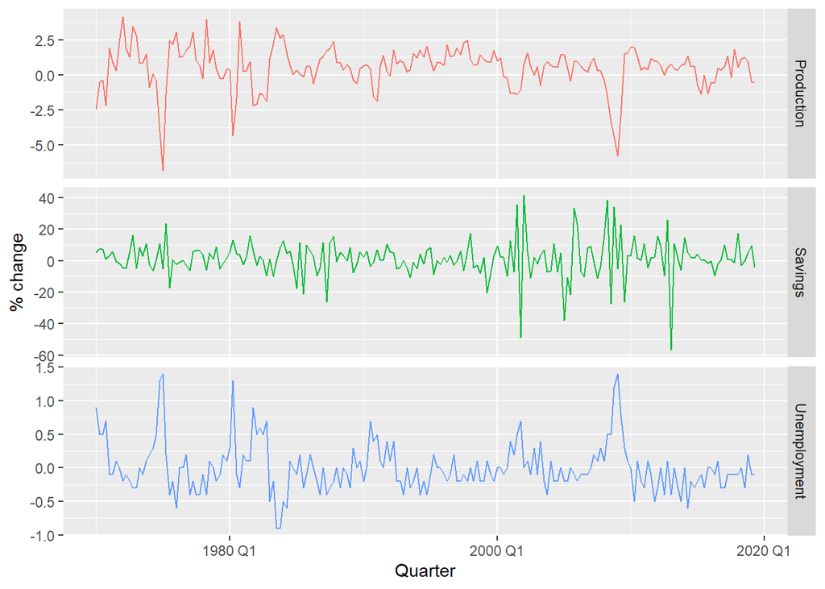

```r
us_change %>%
  select(-Consumption, -Income) %>%
  pivot_longer(-Quarter) %>%
  ggplot(aes(Quarter, value, colour = name)) +
  geom_line() +
  facet_grid(name ~ ., scales = "free_y") +
  guides(colour = "none") +
  labs(y="% change")
```

We can produce a scatterplot matrix of all the variables to study

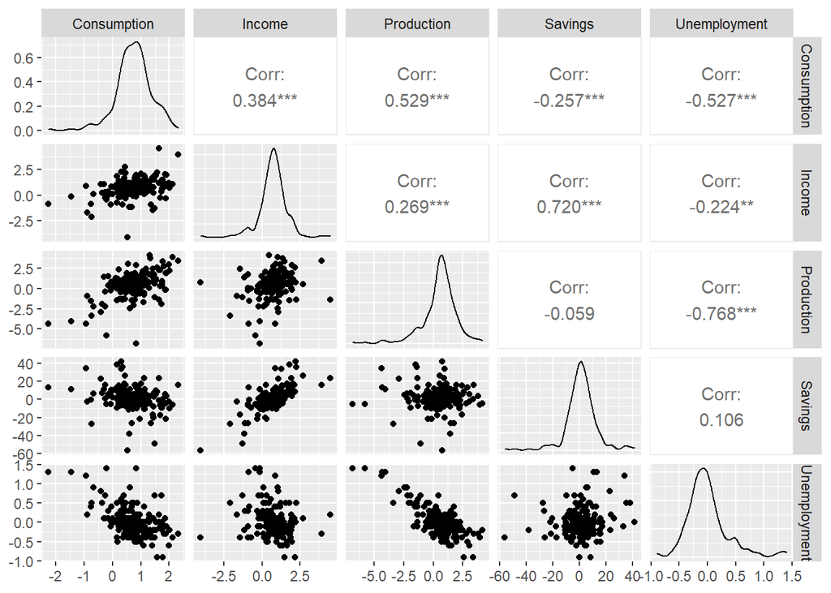

```r
us_change %>%
  GGally::ggpairs(columns = 2:6)
```

A multiple linear regression model for US consumption is:

$$\begin{align*}
y_t=\beta_0 + \beta_1 x_{1,t}+ \beta_2 x_{2,t}+ \beta_3 x_{3,t}+ \beta_4 x_{4,t}+\varepsilon_t
\end{align*}$$

Where the different explanatory variables included are

- the percentage change in real personal disposable income
- the percentage change in industrial production
- the percentage change in personal savings and the change in unemployment rate.

Let us fit the module:

```r
TSLM_4vars <- us_change %>%
  model(tslm = TSLM(Consumption ~ Income + Production +
                                    Unemployment + Savings))

report(TSLM_4vars)
```

```
Series: Consumption
Model: TSLM

Residuals:
     Min       1Q   Median       3Q      Max
-0.90555 -0.15821 -0.03608  0.13618  1.15471

Coefficients:
              Estimate Std. Error t value Pr(>|t|)
(Intercept)   0.253105   0.034470   7.343 5.71e-12 ***
Income        0.740583   0.040115  18.461  < 2e-16 ***
Production    0.047173   0.023142   2.038   0.0429 *
Unemployment -0.174685   0.095511  -1.829   0.0689 .
Savings      -0.052890   0.002924 -18.088  < 2e-16 ***
---
Signif. codes:  0 '***' 0.001 '**' 0.01 '*' 0.05 '.' 0.1 ' ' 1

Residual standard error: 0.3102 on 193 degrees of freedom
Multiple R-squared: 0.7683, Adjusted R-squared: 0.7635
F-statistic:   160 on 4 and 193 DF, p-value: < 2.22e-16
```

- **First Column:** provides the estimation of the coefficients following the Leasts Squares Regression principle**.**
- **Std. Error**: the standard deviation which would be obtained from repeatedly estimating $\beta$ on similar datasets. It gives a measure of the uncertainty in the estimated $\beta$ coefficient.
- **t-value:** ratio of an estimated $\beta$ coefficient to its standard error.
- **p-value:** probability of the estimated $\beta$ coefficient being as large as it is if there were no real relationship between consumption and the corresponding predictor.
  - Particularly useful when studying the effect of each predictor, not particularly useful for forecasting.

## Fitted Values

Using the above estimations of the coefficient and introducing the values of the predictors returns the values for the fitted values. These are *“forecasts”* of the data used to estimate the model (remember that fitted values can be understood as *one-step ahead forecasts*)

As usual, we can obtain the fitted values using the function `augment()`.

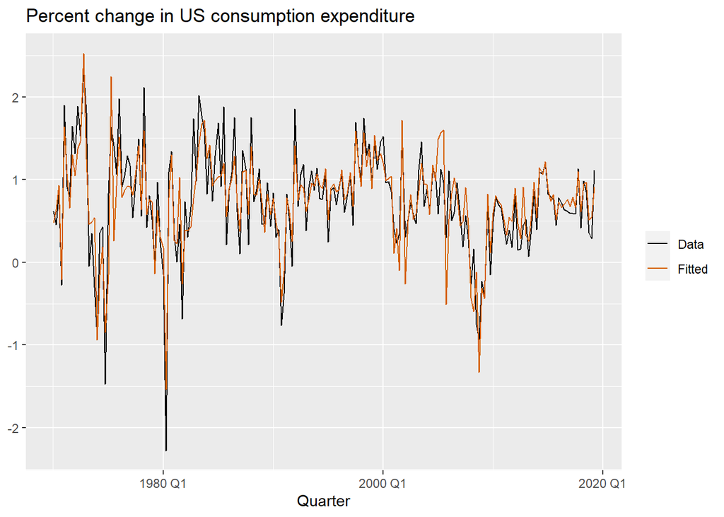

```r
augment(TSLM_4vars) %>%
  ggplot(aes(x = Quarter)) +
  geom_line(aes(y = Consumption, colour = "Data")) +
  geom_line(aes(y = .fitted, colour = "Fitted")) +
  labs(y = NULL,
    title = "Percent change in US consumption expenditure"
  ) +
  scale_colour_manual(values=c(Data="black",Fitted="#D55E00")) +
  guides(colour = guide_legend(title = NULL))
```

# Graphical goodness of fit

Since we are in a multiple linear-regression context, a quick manner to graphically assess how well the fitted values match the data is to generate a scatter-plot with the x-axis corresponding to the original time series $y_t$ and the y-axis corresponding to the fitted vaues yielded by the model. and then depict a line of slope 1. A perfect match would be given if all the points fell upon the same line.

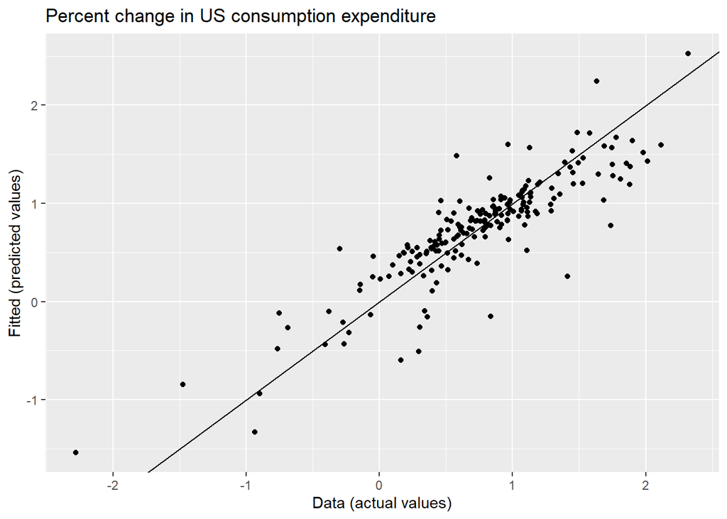

```r
augment(TSLM_4vars) %>%
  ggplot(aes(x = Consumption, y = .fitted)) +
  geom_point() +
  labs(
    y = "Fitted (predicted values)",
    x = "Data (actual values)",
    title = "Percent change in US consumption expenditure"
  ) +
  geom_abline(intercept = 0, slope = 1)
```

# Analytical goodness of fit

## Determination Coefficient

The coefficient of determination $R^2$ is a commo way to summarize how well **a linear regression fits the data** (not how good its predictions/forecasts are):

$$\begin{align*}
R^2 = \frac{\sum(\hat{y}_{t} - \bar{y})^2}{\sum(y_{t}-\bar{y})^2}
\end{align*}$$

The summations occur over all observations. Note that the deviation from the mean is a measure of the vaiability in the data. $R^2$ reflectes therefore the **proportion of variation in the forecast variable that is accounted for (or explained) by the regression model**.

- $R^2 \in [0,1]$

### Caveats of $R^2$

- The value of $R^2$ will never decrease when adding an extra predictor to the model. This can lead to **over fitting** by constraining the model with predictors that do not add explanatory power to the model. * For this reason the **adjusted coefficient of determination** is defined $\bar{R^2}$. More on it later in this notebook.
- There are no general guidelines as for what constitutes a good $R^2$ value. This depends on the type of data used.
- $R^2$ is **only related to the training data.**
  - **Validating the model’s forecasting performance on test data** is **much better than measuring $R^2$** on the training data.

## Standard Error of the Regression:

The **standard devaition of the residuals** also provides us with a measure of how well the model has fitted the data. It is calculated using the formula:

$$\begin{align*}
\hat{\sigma}_e=\sqrt{\frac{1}{T-k-1}\sum_{t=1}^{T}{e_t^2}}
\end{align*}$$

Note the denominator **T-k-1** because we have **estimated k+1 parameters when fitting the model**: the *intercept* and the *coefficient for each predictor variable*. It is nothing else than an adjustment of the degrees of freedom.

The standard error can be compared against:

- the mean of $y_t$ or
- the standard deviation of $y_t$

to gain some perspective on the accuracy of the model. It will be used when generating prediction intervals.

## Adjusted Determination Coefficient

$R^2$ is not a good measure of the predictive ability of a model:

- It mesaures **how well the model fits the training data**, but **not how well the model will forecast future data**
- It **does not allow fo “degrees of freedom”**. $R^2$ tends to increase when **adding any variable**, *even if that variable is irrelevant*
  - Maximising $R^2$ will therefore always lead to the model with most variables, therefore **not being a valid way of selecting predictors**.

An alternative to $R^2$ is the **adjusted determination coefficient** $\bar{R}^2$.

Maximising is equivalent to minimising the standard error. This metric is *based on minimising the standard error* $\hat{\sigma_e}$

Maximising $\bar{R^2}$ is better than maximising $R^2$ for selecting predictors, although it also tends to lead to selecting too many predictors. We will later give some alternatives for selecting predictors.

## Example

Lets print again the reports for the 1-var model and the 4-var models. Adding the three additional regressors has increased the explanatory power of the model from 15% to 76%.

```r
TSLM_1var %>% report()
```

```
Series: Consumption
Model: TSLM

Residuals:
     Min       1Q   Median       3Q      Max
-2.58236 -0.27777  0.01862  0.32330  1.42229

Coefficients:
            Estimate Std. Error t value Pr(>|t|)
(Intercept)  0.54454    0.05403  10.079  < 2e-16 ***
Income       0.27183    0.04673   5.817  2.4e-08 ***
---
Signif. codes:  0 '***' 0.001 '**' 0.01 '*' 0.05 '.' 0.1 ' ' 1

Residual standard error: 0.5905 on 196 degrees of freedom
Multiple R-squared: 0.1472, Adjusted R-squared: 0.1429
F-statistic: 33.84 on 1 and 196 DF, p-value: 2.4022e-08
```

```r
TSLM_4vars %>% report()
```

```
Series: Consumption
Model: TSLM

Residuals:
     Min       1Q   Median       3Q      Max
-0.90555 -0.15821 -0.03608  0.13618  1.15471

Coefficients:
              Estimate Std. Error t value Pr(>|t|)
(Intercept)   0.253105   0.034470   7.343 5.71e-12 ***
Income        0.740583   0.040115  18.461  < 2e-16 ***
Production    0.047173   0.023142   2.038   0.0429 *
Unemployment -0.174685   0.095511  -1.829   0.0689 .
Savings      -0.052890   0.002924 -18.088  < 2e-16 ***
---
Signif. codes:  0 '***' 0.001 '**' 0.01 '*' 0.05 '.' 0.1 ' ' 1

Residual standard error: 0.3102 on 193 degrees of freedom
Multiple R-squared: 0.7683, Adjusted R-squared: 0.7635
F-statistic:   160 on 4 and 193 DF, p-value: < 2.22e-16
```

# Implicit assumptions on the linear models

- The model is a reasonable approximation of reality. (Linear relationship between predictors and forecast variable.)
- **Assumptions about the errors** ($\varepsilon_1,\text{...},\varepsilon_t$):
  - $E(\varepsilon_i) = 0$ (null expectation).
  - No autocorrelation of the errors (otherwise the model is not properly capturing information).
  - Residuals unrelated to the predictor variables. Otherwise there would be more information that should be included on the model.
- Another useful property for computing confidence intervals is to have *normally distributed errors* with a *constant variance $\sigma$* (homoscedasticity).
- It is assumed that **each predictor $x$ is not a random variable**. This will be the **main difference with the autoregressive models** we will see in arima, where the regressors will be random variables, leading to some difficulties. Essentially we will have to put restrictions on the AR parameters for the model to have sensible properties, whereas in linear regression there are no parameters restrictions.

# Residuals analysis

$$\begin{align*}
e_t &= y_t - \hat{y}_t \\
&= y_t - \hat\beta_{0} - \hat\beta_{1} x_{1,t} - \hat\beta_{2} x_{2,t} - \cdots - \hat\beta_{k} x_{k,t}
\end{align*}$$

for $t=1,\text{...},T$. Each residual is the **unpredictable component of the associated observation**.

## Two properties of the residuals

To estimate the parameters in the context of least squares estimation, we impose the condition of minimizing the sum of square residuals:

$$\begin{align*}
RSS = \sum_{i=1}^ne_i^2
\end{align*}$$

Deriving by each of the parameters and equating to 0, we immediatly obtain the following properties of the residuals:

$$\begin{align*}
RSS=\displaystyle\sum\limits_{i=1}^n \left(e_i \right)^2= \sum_{i=1}^n\left(y_i - \hat{y_i} \right)^2= \sum_{i=1}^n\left(y_i -\beta_0- \beta_1x_{i,1}-\beta_2x_{i,2}-…- \beta_px_{i,p} \right)^2
\end{align*}$$
$$\begin{align*}
\frac{\partial{SSE}}{\partial{\beta_0}} = \sum_{i=1}^n 2\left(y_i -\beta_0- \beta_1x_{1,i}-\beta_2x_{2,i}-…- \beta_px_{p,i} \right)^1 (-1) =-2\displaystyle\sum\limits_{i=1}^ne_i=0
\end{align*}$$
$$\begin{align*}
\frac{\partial{SSE}}{\partial{\beta_k}} = \sum_{i=1}^n 2\left(y_i -\beta_0- \beta_1x_{1,i}-\beta_2x_{2,i}-…- \beta_px_{p,i} \right)^1 (-x_{k,i}) =-2\displaystyle\sum\limits_{i=1}^ne_i(-x_{k,i})=0
\end{align*}\text{ (for k } \neq 0)$$

Thus we obtain the following very relevant properties applicable in the context of least squares linear regression:

$$\begin{align*}
\sum_{t=1}^{T}{e_t}=0 \quad\text{and}\quad \sum_{t=1}^{T}{x_{k,t}e_t}=0\qquad\text{for all $k$}
\end{align*}$$

From these properties we see immediatly:

- The mean of the residuals in the context of least squares is 0.
- The correlation between the residuals and the observations for the predictor variable is 0 (this is not necessarily true if the intercept is ommited for the model).

Let us generate `gg_tsresiduals()` to produce the essential plots for ts residuals analysis:

The following graphs help inspect the residuals:

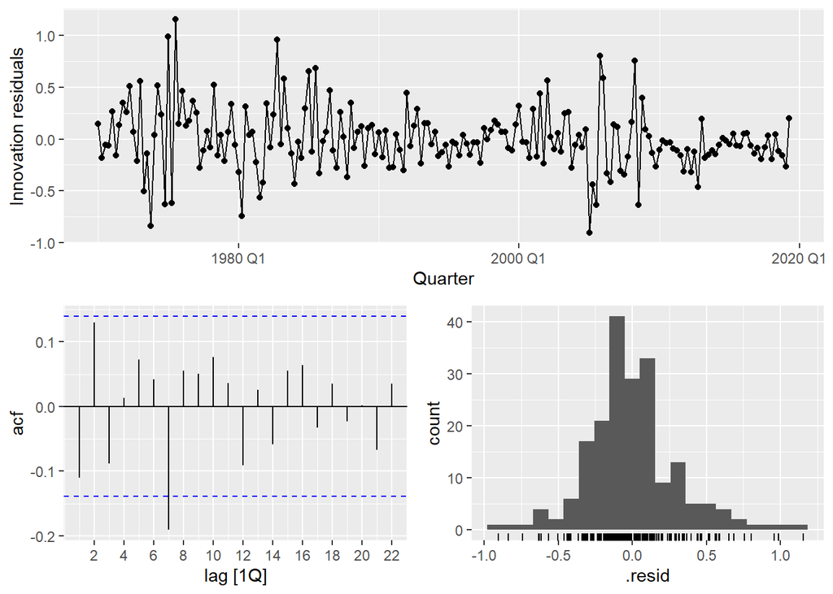

```r
TSLM_4vars %>% gg_tsresiduals()
```

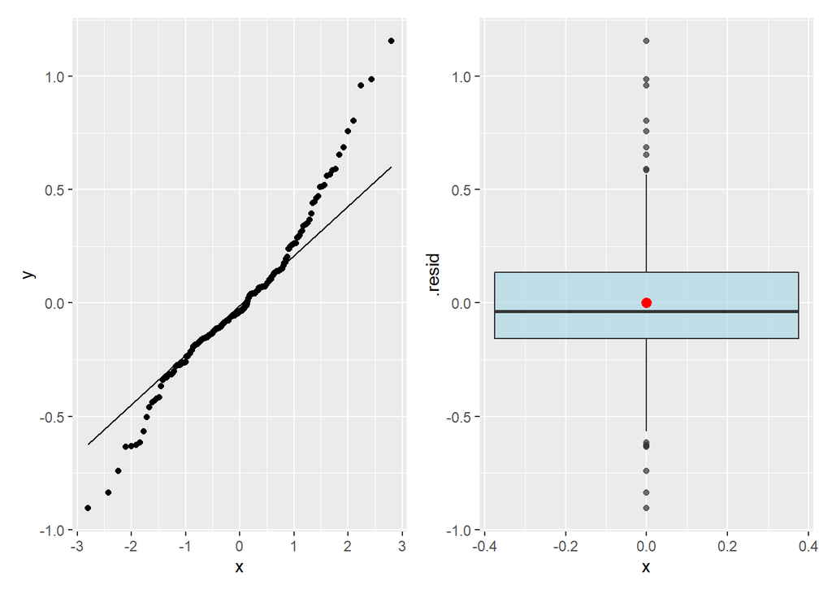

```r
# QQPlot
p1 <- TSLM_4vars %>%
        augment() %>%
        select(.resid) %>%
        ggplot(aes(sample = .resid)) +
        stat_qq() +
        stat_qq_line()

# Generate box-plot
p2 <- TSLM_4vars %>%
        augment() %>%
        select(.resid) %>%
        ggplot(aes(y = .resid)) +
        geom_boxplot(fill="light blue", alpha=0.7) +
        stat_summary(aes(x=0), fun="mean", color="red")

p1 + p2 # Use library patchwork to place graphs together
```

## ACF of the residuals

Autocorrelation is common in the residuals of a regression model fitted to time series data. If there is autocorrelation in the errors, **there is information left in the residuals which should have been captured by the model to obtain better forecasts**.

The resulting **forecasts** are still **unbiased** (their mean is after all 0) and so are not wrong, but the model is improvable. WIth a better model prediction intervals could be narrower.

In this case there a significant spike at lag 7, in the sense that it exceeds the region of negligible autocorrelation. However the ACF at this lag still remains of the same order of magnitude as the wide of the region itself, so it is not necessarily particularly remarcable.

The ljung-pierce statistic on the other hand, with the recommended value of 10 results in a p-value that rejects $H_0$, so we could conclude that the autocorrelation is relevant.

```r
TSLM_4vars %>%
  augment() %>%
  features(.resid, ljung_box, lag = 10, dof = 5)
```

```
# A tibble: 1 x 3
  .model lb_stat lb_pvalue
  <chr>    <dbl>     <dbl>
1 tslm      18.9   0.00204
```

However if we examine the first 100 lags we fulfil two conditions:

- 95% of the ACF coefficients are within bounds
- The values of ACF that exceed the boundary do not do so by much.

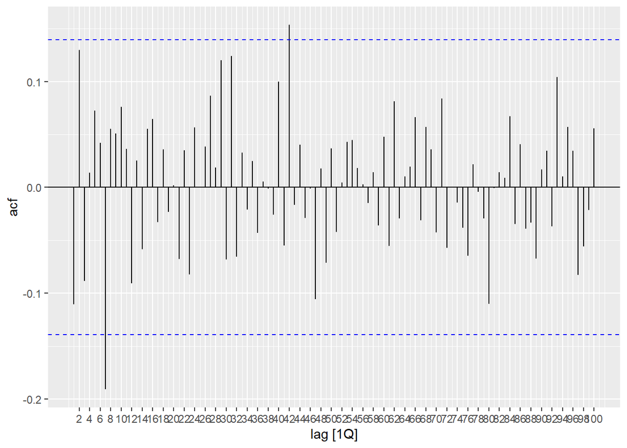

```r
TSLM_4vars %>%
  augment() %>% ACF(.resid, lag_max=100) %>% autoplot()
```

Since the t-series has around 200 points and the ljung-box statistic remains fairly accurate as long as $T/l > 5$ we are going to extend the test a bit further into the future, to see if this has any noticeable effect

```r
TSLM_4vars %>%
  augment() %>%
  features(.resid, ljung_box, lag = 20, dof = 5)
```

```
# A tibble: 1 x 3
  .model lb_stat lb_pvalue
  <chr>    <dbl>     <dbl>
1 tslm      24.0    0.0657
```

Combining all these pieces of information we may conclude that, for this particular case, we can consider the residuals as uncorrelated.

When we discuss *dynamic regression models* we will see the most common approach to reducing the amount of information left in the residuals.

## Time plot of the residuals

The timeplot can be used to **examine whether the residuals exhibit cluters of heteroscedasticiy over certain periods of time.** This particular graph is generated when dealing with time series regression models, where time is the underlying dimension.

In this case the time plot shows some changing variance over time, which may render the coverage of the prediction intervals innacurate.

## Histogram of the residuals

The histogram helps us check if the residuals are normally distributed. This assumption is not critical but it helps calculate prediction intervals.

If this assumption is violated, prediction intervals may be calculated by bootstrapping residuals.

In this case, the histogram, qq-plot and box-plot show residuals that are slightly skewed, which may affect the coverage probability of the prediction intervals.

## Residuals plots against predictors

Plotting the residuals plots against the predictors generates a graph that **gives information about the accuracy of the fitted values throughout the range of values of each predictor**.

- **Ideally** the model would **perform well across the entire range of values of the predictor variable**
  - Therefore, **ideally there would be no pattern in such a graph** and the residuals would be randomly scattered without any systemattic pattern.
  - **If there i a pattern** then **the relationship between the forecast variable and that particular predictor may be non-linear** and **the model will need to be modified accordingly**. The reasoning is: *we have fitted a linear model and the residuals of that linear model exhibit a non-linear pattern that has not been captured by the model*.

It is also necessary to **plot the residuals against predictors that are not in the model**. If these show a pattern then the predictor may be needed to be added to the model (possibly in a non-linear form).

### Example

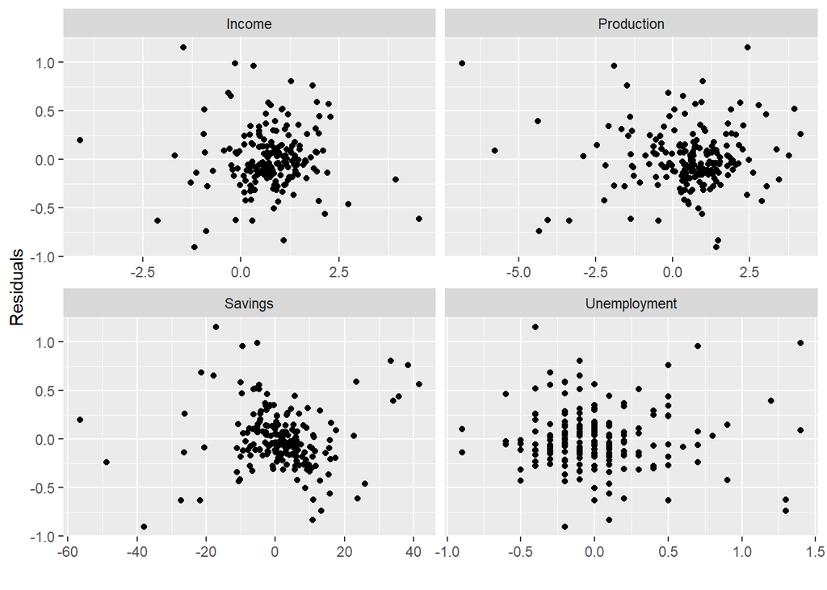

```r
us_change %>%
  left_join(residuals(TSLM_4vars), by = "Quarter") %>%
  pivot_longer(Income:Unemployment,
               names_to = "regressor", values_to = "x") %>%
  ggplot(aes(x = x, y = .resid)) +
  geom_point() +
  facet_wrap(. ~ regressor, scales = "free_x") +
  labs(y = "Residuals", x = "")
```

The residuals in this case seem to be randomly scattered.

## Residuals plots against fitted values

Plotting the residuals against the fitted values gives **information about the accuracy of the fit throughout the range of the fitted values**.

- If these graphs exhibit a pattern, the may be “heteroscedasticity” in the sense that *for some ranges of the fitted values the residuals might be larger than for other ranges*.
  - Note that this is different than looking for time periods where the residuals are larger, which is what we do when looking at the time-plot of the residuals (looking for time-clusters with larger residuals).

If this occurs a transformation of the forecast variable (logarithm, square root, box-cox…) may be required.

### Example

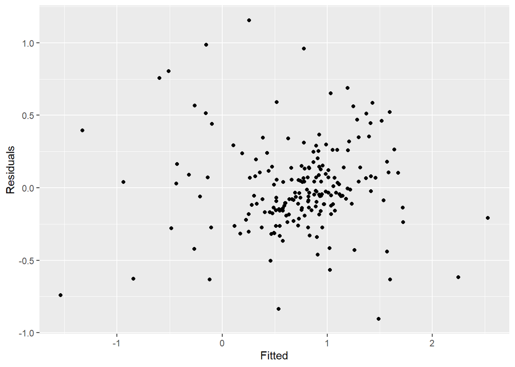

```r
augment(TSLM_4vars) %>%
  ggplot(aes(x = .fitted, y = .resid)) +
  geom_point() + labs(x = "Fitted", y = "Residuals")
```

The random scatter suggests the errors are homoscedastic.